## Chick weights

The `ChickWeight` data set is part of the base package `datasets`. See `?ChickWeight` for details on the data. For all of the questions use `dplyr` functions with the pipe `%>%` whenever possible.

```r
library(datasets)
library(ggplot2)
suppressWarnings(suppressMessages(library(dplyr)))
```

1. Get a frequency breakdown of the number of chicks, their average weight and the standard deviation of the weights in each of the diets at the start of the study. Store the resulting data frame in a variable named `weight0` and print.

```r
# Create dataframe
weight0 = data.frame(ChickWeight)

# Modify with average and standard deviation of weight at Time == 0
weight0 = weight0 %>% filter(Time == 0) %>% group_by(Diet) %>% summarize(avg_weight = mean(weight, na.rm = TRUE), sd_weight = sd(weight, na.rm = TRUE))

# Display dataframe
print(weight0, n=Inf)
```

```
## # A tibble: 4 x 3
##   Diet  avg_weight sd_weight
##   <fct>      <dbl>     <dbl>
## 1 1           41.4     0.995
## 2 2           40.7     1.49
## 3 3           40.8     1.03
## 4 4           41       1.05
```

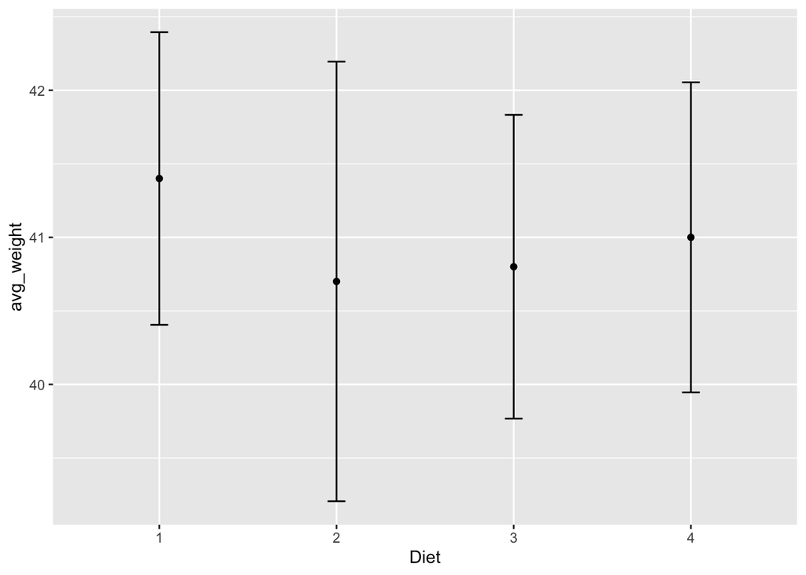

```r
# Graph the starting weights by diet with standard deviation from the mean (EXTRA CREDIT IMPLEMENTED)
ggplot(weight0, aes(x=Diet, y=avg_weight)) + geom_point() + geom_errorbar(aes(ymin = avg_weight - sd_weight, ymax = avg_weight + sd_weight), width=0.1)
```

2. Each chick should have twelve weight measurements. Use the `dplyr` package to identify how many measurements are there for each chick. Extract a subset of the data for all chicks with complete information, name the data set `complete`, and print the first 3 rows. (Hint: you might want to use mutate to introduce a helper variable consisting of the number of observations)

```r
# Create num_observations for each chick
complete = ChickWeight %>% group_by(Chick) %>% mutate(num_observations = n()) %>% ungroup()

# Get rows with num_observations of 12
complete = complete[complete$num_observations == 12, ]

# Display results
print(complete, n=3)
```

```
## # A tibble: 540 x 5
##   weight  Time Chick Diet  num_observations
##    <dbl> <dbl> <ord> <fct>            <int>
## 1     42     0 1     1                   12
## 2     51     2 1     1                   12
## 3     59     4 1     1                   12
## # … with 537 more rows
```

3. In the complete data set introduce a new variable that measures the current weight difference compared to day 0. Name this variable `weightgain` and print the first 3 rows of the new data frame.

```r
# Get weight at day 0 for each chick
complete$day_0_weight = 0
weights = vector(mode='numeric')
index = 1

# For every chick
for (i in 1:max(complete$Chick)) {

  # Skip chicks without 12 entries
  if (i %in% c(8, 15, 16, 18, 44)) {
    next
  }

  # Get the weight of the chick at day 0
  weight_temp = complete %>% filter(Time == 0) %>% filter(Chick == i) %>% select(weight)
  weight_temp = as.numeric(weight_temp)

  # Set the weight at day 0 for each entry
  for (j in 1:12) {
    weights[index] = weight_temp
    index = index + 1
  }
}

# Assign colunmn to vector
complete$day_0_weight = weights

# Get difference in day 0 weight
complete = complete %>% group_by(Chick) %>% mutate(weightgain = weight - day_0_weight) %>% ungroup()

# Remove temp columns
complete$day_0_weight = NULL

# Display results
print(complete, n=3)
```

```
## # A tibble: 540 x 6
##   weight  Time Chick Diet  num_observations weightgain
##    <dbl> <dbl> <ord> <fct>            <int>      <dbl>
## 1     42     0 1     1                   12          0
## 2     51     2 1     1                   12          9
## 3     59     4 1     1                   12         17
## # … with 537 more rows
```

4. Use `{ggplot2}` to create side-by-side boxplots of `weightgain` by `Diet` for day 21. Change the order of the categories in the Diet variable such that the boxplots are ordered by median `weightgain`, and the lower limit of the y axis should be 0. Describe the relationship in 2-3 sentences.

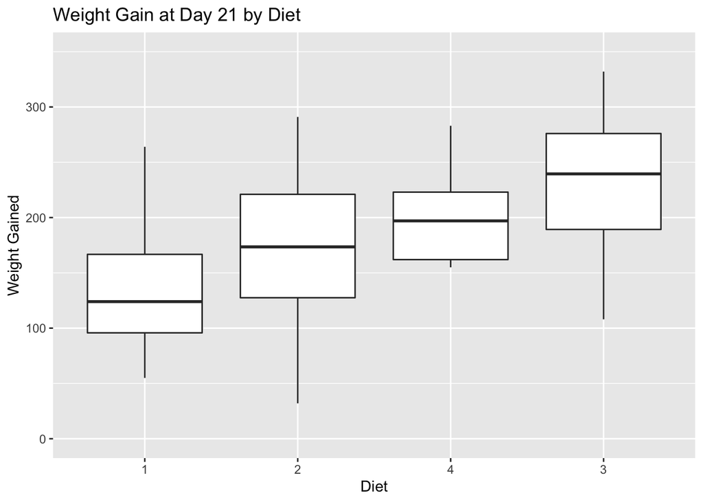

```r
day_21 = complete[complete$Time == 21, ]
day_21$Diet = factor(day_21$Diet, levels=c(1, 2, 4, 3))
ggplot(day_21, aes(x=Diet, y=weightgain)) + geom_boxplot() + ylim(0, 350) + ggtitle('Weight Gain at Day 21 by Diet') + ylab('Weight Gained')
```

5. Answer each of the following questions using numerical and graphical summary. Also explain what you found: (a) Which chick gained the most weight and which gained the least weight? (b) What diets were they on?

```r
# Get max gained weight data
max_gained_weight = day_21[day_21$weightgain == max(day_21$weightgain), ]
max_chick = max_gained_weight$Chick
max_diet = max_gained_weight$Diet

# Display max data
print(paste('Most weight gained by chick number', max_chick, 'on diet', max_diet))
```

```
## [1] "Most weight gained by chick number 35 on diet 3"
```

```r
# Get min gained weight data
min_gained_weight = day_21[day_21$weightgain == min(day_21$weightgain), ]
min_chick = min_gained_weight$Chick
min_diet = min_gained_weight$Diet

# Display max data
print(paste('Least weight gained by chick number', min_chick, 'on diet', min_diet))
```

```
## [1] "Least weight gained by chick number 24 on diet 2"
```

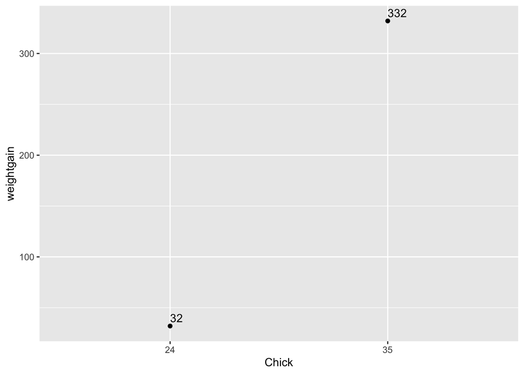

```r
day_21_small = day_21[day_21$Chick == min_chick | day_21$Chick == max_chick, ]
ggplot(day_21_small, aes(x=Chick, y=weightgain, label=weightgain)) + geom_point() + geom_text(aes(label=weightgain, hjust=0, vjust=-0.5))
```

6. For the chicks with the least and the most weight at time 0, plot their growth trajectories over time.

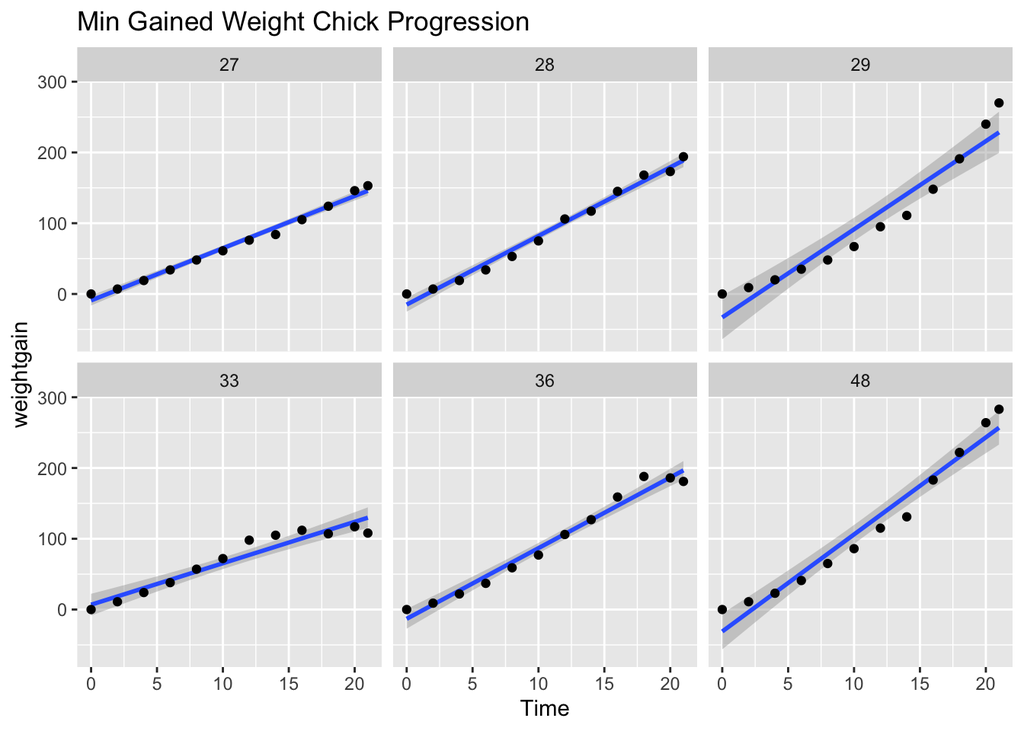

```r
min_chicks = ChickWeight %>% filter(Time == 0) %>% filter(weight == min(weight))
max_chicks = ChickWeight %>% filter(Time == 0) %>% filter(weight == max(weight))
chick_progression_min = complete[complete$Chick %in% min_chicks$Chick, ]
chick_progression_max = complete[complete$Chick %in% max_chicks$Chick, ]

ggplot(chick_progression_min, aes(x=Time, y=weightgain)) + geom_smooth(method='lm') + geom_point() + facet_wrap(~Chick) + ggtitle('Min Gained Weight Chick Progression')
```

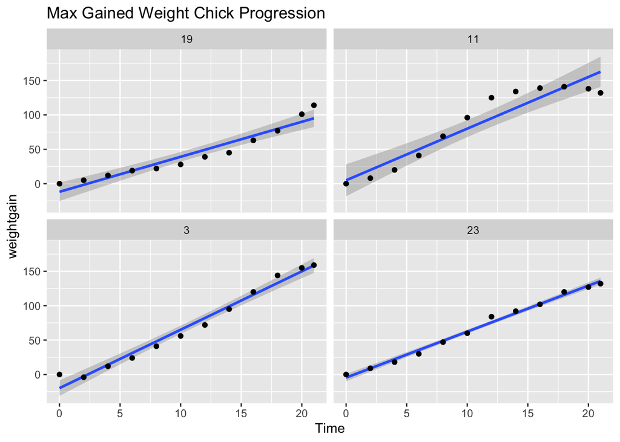

```r
ggplot(chick_progression_max, aes(x=Time, y=weightgain)) + geom_smooth(method='lm') + geom_point() + facet_wrap(~Chick) + ggtitle('Max Gained Weight Chick Progression')
```

7. Add to the previous plot the average growth trajectory for all chicks (calculated as the mean weight for each chick at each time). How do the trajectories compare?

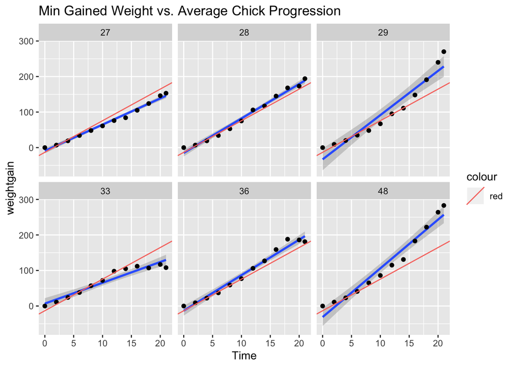

```r
averages = complete %>% group_by(Time) %>% mutate(avg_gain = mean(weightgain)) %>% ungroup()

ggplot(chick_progression_min, aes(x=Time, y=weightgain)) + geom_smooth(method='lm') + geom_point() + facet_wrap(~Chick) + ggtitle('Min Gained Weight vs. Average Chick Progression') + geom_abline(aes(intercept=-13.323114506122534, slope=8.896086824988428, color='red'))
```

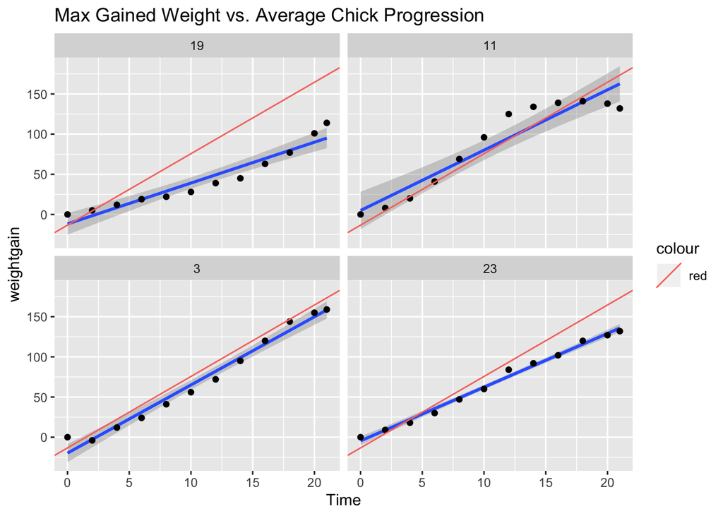

```r
ggplot(chick_progression_max, aes(x=Time, y=weightgain)) + geom_smooth(method='lm') + geom_point() + facet_wrap(~Chick) + ggtitle('Max Gained Weight vs. Average Chick Progression') + geom_abline(aes(intercept=-13.323114506122534, slope=8.896086824988428, color='red'))
```

8. What else do you find interesting in the dataset? Show your exploratory analysis.

The given data isn’t enough to predict anything too far into the future, but the current model predicts endless growth for the chicks. For example, the graph of chick labelled 1 shows that its weight would continue to grow infinitely with the given data. Data farther into the future would need to be included in the model to be able to find the maximum weight and possibly predict this for other chicks given starting data and diet.

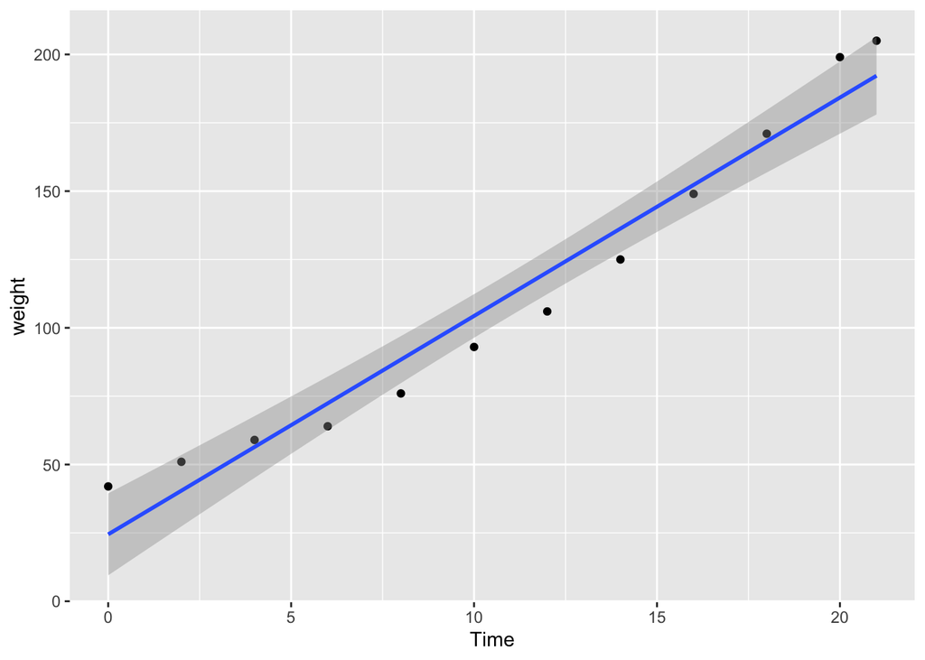

```r
chick1 = ChickWeight %>% filter(Chick == 1)
ggplot(chick1, aes(x=Time, y=weight)) + geom_point() + geom_smooth(method='lm')
```

Note: your submission is supposed to be fully reproducible, i.e. the TA and I will ‘knit’ your submission in RStudio.